# Tutorial19-Classes

```python
#importing the usaul libraries
import matplotlib.pyplot as plt
import numpy as np
```

## 2 think+type: a Walker class

```python
#defining and typing the walker class

class Walker:

    '''
    The Walker class creates random walker objects that can move about in 1D space,
    and records where they have been, and when they were there
    '''

    def __init__(self, stepsize=0.1):

        '''
        Initialize a random Walker object. When the walker takes steps,
        they will be drawn from a Gaussian distribution with a width of
        "stepsize".


        Optional Inputs:
        stepsize = average step size this walker takes, in arbitrary units

        The default step size without an input is stepsize=0.5
        '''
        #print(self, stepsize) #testing to make sure the __init__(self, stepsize=0.5) is taking the correct inputs


        # store the initialized step size
        self.stepsize = stepsize #defining a new attribute for self called stepszie
        # set the current position to 0.0
        self.x = 0.0
        # create a list to store where this walker has been
        # Initialize it with the starting position of 0.0
        # the index values of the list self.history records when they were there
        self.history = [self.x]


    def takeStep(self):


        '''

        takeStep(self) makes the walker take one random step with the
        predefined step size

        '''
        # step will be a random number, with amplitude of stepsize
        step = self.stepsize*np.random.normal(0, 1) # this creates a random number between -1 and 1 under a normal distriubution
        # modify the current position
        self.x += step
        # store the step
        self.history.append(self.x)


    def takeWalk(self, N):

        '''

        This will have the walker take N random steps

        '''
        # take N steps
        for i in range(N):
            self.takeStep()


    def plotHistory(self):

        '''

        plotHistory(self)   plots the position on a graph with the number os steps N
        on the x-axis and the position on the y -axis

        '''
        # how many steps has this walker taken?
        N = len(self.history) - 1 # the first position in self.history is the starting point
        # plot a horizontal line at 0
        plt.axhline(0, color='gray')
        # plot all the positions the walker has visited
        plt.plot(self.history, alpha=0.3)
        # plot the current position
        plt.scatter(N, self.x)
        # label the axes
        plt.xlabel('N (# of steps taken)')
        plt.ylabel('1D position')
```

self. Syntax is creating a list of methods for the Walker class I believe.

#### Initial testing of the walker class

I got confused here so I put my code into [Python Tutor](https://pythontutor.com/render.html#mode=display)

```python
walker1 = Walker("Luca") # setting walker to a Walker class
```

```python
walker1.__init__()
```

```python
walker1.takeStep()# trying to have my walker1, "Luca" take his first step (also that sounds so weird to refer to myself in the third person)
```

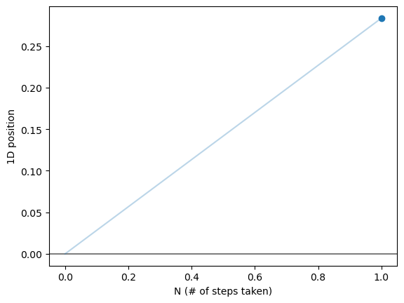

```python
walker1.plotHistory() # Hopefully, this creates a graph with one point
```

OMG that actually worked!!! I have been working on this for like the last hour, trying to get this working and learning to understand how classes and objectss within a class work so seeing that plot makes me so excited!!!

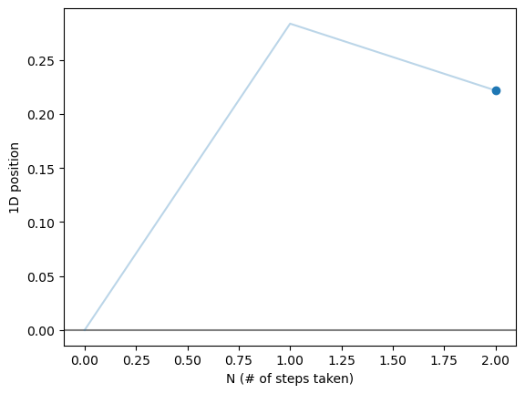

```python
walker1.takeStep()
walker1.plotHistory()
```

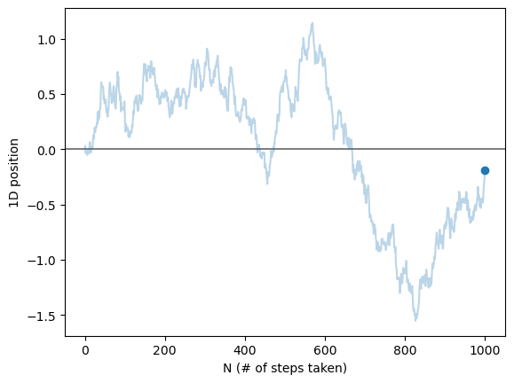

```python
#trying to make myself a walker again

Luca = Walker(stepsize = 0.05)

#getting my steps in
Luca.takeWalk(1000)

Luca.plotHistory()
```

## 3 think+pair+write: attributes vs methods

I did this by myself after class

Ok, so I am using Luca instead of a mouse, as I defined Luca

Luca.x Luca.x holds the current position of the Walker(Luca)

Luca. history Luca.History is a list of all of the Luca.x values and has length N+1

Luca. takeWalk(self, N) the Luca.takeWalk method, repeats the Luca,takeStep method N number of times. For every time(N) it uses the Luca.takeStep method, it adds to result to Lica.,x and appends the Luca.histopry list with the new value of Luca.x

Luca. .plotHistory() The Luca.plotHistory method uses matplotlib.pyplot to generate a plot of Luca.x on the y-axis vs. N on the x-axis

## 4 think+type: A giant with giant steps

```
the final position of the igant is, 3740.995047091854
```

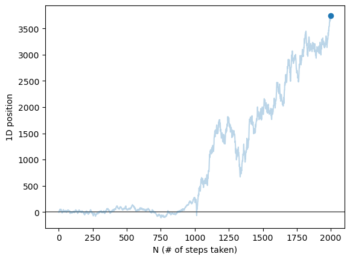

```python
#creating a giant walker with massive step sizes

giant = Walker(stepsize=10.0) # assigning the giant its first step size

giant.takeWalk(1000) # making the giant walk 1000 random steps

#giatn with new step size

giant.stepsize=50.0 # reassigning the giant's step size to 50

giant.takeWalk(1000) #having the giant take another 1000 steps


#plotting the giant's journey
giant.plotHistory() # This should be somewhat different as the step size has changed, so I am expecting to see larger variation on the right side of the graph when N>1000

print(f"the final position of the igant is, {giant.x}") #this should print the last value of giant.x
```

```
the final position of the igant is, 1205.8579690629545
```

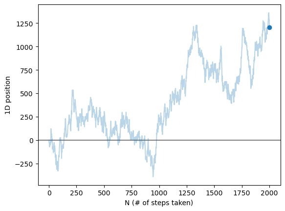

```python
#second run through of the giant

giant = Walker(stepsize=30.0) # assigning the giant its first step size 50 +10/2 = 30

giant.takeWalk(1000) # making the giant walk 1000 random steps

#giatn with new step size

giant.stepsize=30.0 # reassigning the giant's step size to 30

giant.takeWalk(1000) #having the giant take another 1000 steps


#plotting the giant's journey
giant.plotHistory() # This should be somewhat different as the step size has changed so I am expecting to see larger variation on the right side of the graph when N>1000

#checking if the giant reaches the same endpoint at the average speed the giant was going last time
print(f"the final position of the igant is, {giant.x}") #this should print the last value of giant.x
```

```
the final position of the igant is, 822.6658111673459
```

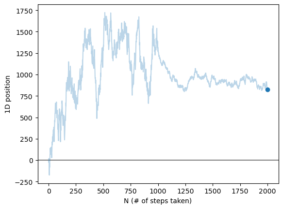

```python
#third run through of the giant

giant = Walker(stepsize=50.0) # assigning the giant its first step size

giant.takeWalk(1000) # making the giant walk 1000 random steps

#giatn with new step size

giant.stepsize=10.0 # reassigning the giant's step size to 10

giant.takeWalk(1000) #having the giant take another 1000 steps


#plotting the giant's journey
giant.plotHistory() # This should be somewhat different as the step size has changed so I am expecting to see larger variation on the right side of the graph when N>1000

#checking how to graph looks if the giant starts out at a fast speed, then slows down
print(f"the final position of the igant is, {giant.x}") #this should print the last value of giant.x
```

```
the final position of the igant is, 894.1318455526501
```

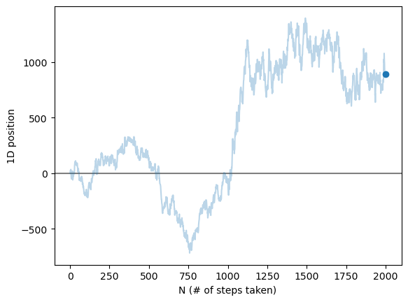

```python
#fourth run through of the giant

giant = Walker(stepsize=20.0) # assigning the giant its first step size

giant.takeWalk(1000) # making the giant walk 1000 random steps

#giatn with new step size

giant.stepsize=40.0 # reassigning the giant's step size to 40

giant.takeWalk(1000) #having the giant take another 1000 steps


#plotting the giant's journey
giant.plotHistory() # This should be somewhat different as the step size has changed so I am expecting to see larger variation on the right side of the graph when N>1000


print(f"the final position of the igant is, {giant.x}") #this should print the last value of giant.x
```

## 5 think+write: the wandering giant

I then calculated that for the total 1000 steps, the giant had an average speed of (50+10)/2 Distance/N. So I made sure all of my future runs kept that average speed as I wanted to seee how the final positions varied.

```python
# I googled, "how to create a data table in python," to create a data table to more clearly organize my results
print("\n")
print("data from my four run throughs of the giant walking at varried speeds:")
print("\n")

import pandas as pd

data = {
        'run number': ['1', '2', '3', '4'],
        'first stepsize': [10.0, 30.0, 50.0, 20.0],
        'second stepsize': [50.0, 30.0, 10.0, 40.0],
        'final position': [3741, 1206, 823, 894]
    }

df = pd.DataFrame(data)
print(df)
```

```
data from my four run throughs of the giant walking at varried speeds:


  run number  first stepsize  second stepsize  final position
0          1            10.0             50.0            3741
1          2            30.0             30.0            1206
2          3            50.0             10.0             823
3          4            20.0             40.0             894
```

All four of my run-throughs look different. The first run through stays mostly flat until 1000 steps, at which point it spikes. This is because the step size changes from 10 steps to 50 steps. My second run through looks similar to my first run through just with a less flat first 1000 steps. This is because in my second run through I kept my step size constant. This makes the variation look more like random spikes rather than clear points of change. For my 3rd run through, I started at a speed of 50 steps per N and then decreased it to 10 steps per N. This caused massive spikes at the beginning, which flattened out past N = 1000. For my fourth run through, I started at a speed of 20 steps per N. Then after N = 1000, I increased it to a speed of 40 steps per N. This created a similar plot to the first run through, just with a less flat first 1000 steps and a less steep last 1000 steps.

## 6 think+pair+code: add methods to a class

#### I did this by myself

```python
#defining and typing the walker class

class newWalker:

    '''
    The Walker class creates random walker objects that can move about in 1D space,
    and records where they have been, and when they were there
    '''

    def __init__(self, stepsize=0.1):

        '''
        Initialize a random Walker object. When the walker takes steps,
        they will be drawn from a Gaussian distribution with a width of
        "stepsize".


        Optional Inputs:
        stepsize = average step size this walker takes, in arbitrary units

        The default step size without an input is stepsize=0.5
        '''
        #print(self, stepsize) #testing to make sure the __init__(self, stepsize=0.5) is taking the correct inputs


        # store the initialized step size
        self.stepsize = stepsize #defining a new attribute for self called stepszie
        # set the current position to 0.0
        self.x = 0.0
        # create a list to store where this walker has been
        # Initialize it with the starting position of 0.0
        # the index values of the list self.history records when they were there
        self.history = [self.x]


    def takeStep(self):


        '''

        takeStep(self) makes the walker take one random step with the
        predefined step size

        '''
        # step will be a random number, with amplitude of stepsize
        step = self.stepsize*np.random.normal(0, 1) # this creates a random number between -1 and 1 under a normal distriubution
        # modify the current position
        self.x += step
        # store the step
        self.history.append(self.x)


    def takeWalk(self, N):

        '''

        This will have the walker take N random steps

        '''
        # take N steps
        for i in range(N):
            self.takeStep()


    def plotHistory(self):

        '''

        plotHistory(self)   plots the position on a graph with the number os steps N
        on the x-axis and the position on the y -axis

        '''
        # how many steps has this walker taken?
        N = len(self.history) - 1 # the first position in self.history is the starting point
        # plot a horizontal line at 0
        plt.axhline(0, color='gray')
        # plot all the positions the walker has visited
        plt.plot(self.history, alpha=0.3)
        # plot the current position
        plt.scatter(N, self.x)
        # label the axes
        plt.xlabel('N (# of steps taken)')
        plt.ylabel('1D position')

    def steps(self):
        '''
        calculates the total amount of steps taken

        Returns steps taken as an int data type

        '''
        taken = len(self.history)
        return(taken)

    def expectedDistance(self, N):
        '''
        N = integer
        N is the number of steps

        Returns the average distance as a float

        '''
        avg_dist = self.stepsize*np.sqrt(N)

        return( float(avg_dist))
```

```python
walker2 = newWalker("test")
```

```python
walker2.__init__() # I forgot to initliaze walker2 lmao
```

```python
walker2.steps() # This should return 1 because it has the starting point
```

```
1
```

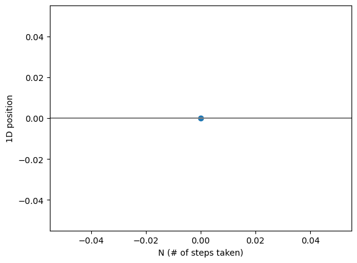

```python
walker2.plotHistory() #checking to make sure there is 1 point
```

```python
walker2.takeWalk(5)
```

```python
walker2.steps() # This should return 6 because it has the starting point and five steps
```

```
6
```

```python
print(walker2.stepsize) #checking to make sure that walker2.__init__ defined the attribute stepsize for walker2
```

```
0.1
```

```python
walker2.expectedDistance(4) #this should return 0.2 if I understand what the code is doing
```

```
0.2
```

```
28
 the amount of walker inside the expected range is, 36
 the amount of walkers out side the expected range is 14
```

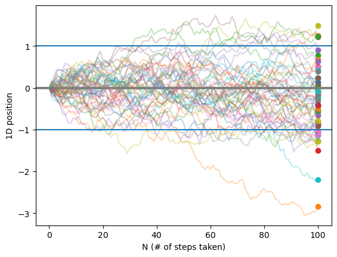

```python
walker2 = newWalker(stepsize = 42) # changing the stepsize for walker2
# Also, if you can't tell, we are all nerds. I saw, "w = newWalker(stepsize=1)" in the tutorial and thought, no, let's have a more fun number, so I picked 42. Then it said, "w.takeWalk(42)" I just about diedd with laughter.

walker2.takeWalk(27) # I don't want to do 42 again. Sorry I am also a nerd so I used 42 for the step size

print(walker2.steps()) #this sould print 27

distances = [] # creating a list for distances

e = walker3.expectedDistance(100) # The walkers are taking 100 steps, so I will plot the expected distance for 100 steps
count_in = 0
count_out = 0

for i in range(50):
    walker3 = newWalker() #one more walker, a third walker, walker3
    walker3.takeWalk(100)
    walker3.plotHistory()
    distances.append(walker3.x)
    if -e <= walker3.x <= e: #counting the amount of walkers between -e and e
        count_in += 1
    else:
        count_out += 1

plt.axhline(e)
plt.axhline(-e)
print(f" the amount of walker inside the expected range is, {count_in} \n the amount of walkers out side the expected range is {count_out} ")
```

well, it looks like the majority of the walkers are between -e and e, which is the expected range. I added some counting variables to count the number of walkers inside the expected range. The amount of walkers in the expected range is 36. 36/50 *100 = 72%. Considering that for a Gaussian, aka normal, distribution, 68% of the data should fall within one standard deviation, I believe that this is pretty close. So I would assume over more trials the data will move towards a normal distribution.